# Introduction to the npfda Package

Rubén Fernández-Casal (ruben.fcasal@udc.es)

Sergio Castillo-Páez (sacastillo@espe.edu.ec)

Miguel Flores (miguel.flores@epn.edu.ec)

npfda 0.1.4

This vignette (a working draft) tries to illustrate the use of the `npfda` (Nonparametric functional data analysis) package. This package implements nonparametric methods for inference on functional processes, avoiding the misspecification problems that may arise when using parametric models.

# Introduction

```r
library(npfda)
```

The `ozone` data set, supplied with the `npfda` package, will be used in the examples in this document. The data consist of daily averages of ozone concentration (microgram per cubic meter) recorded over the period from 1988 to 2020 at the Yarner Wood AURN monitoring site in the UK.

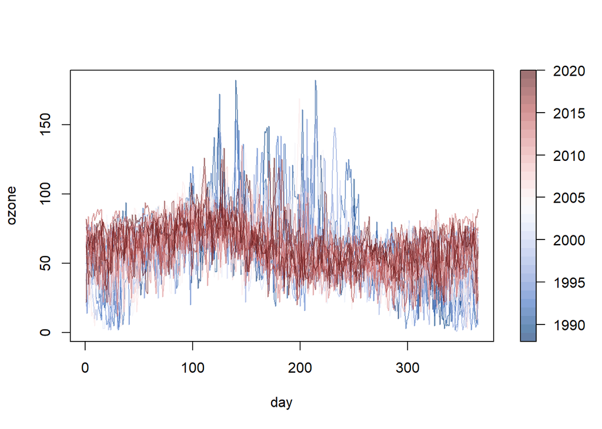

```r
fd <- npf.data(ozone, dimnames = "day")
plot(fd, y = as.numeric(fd$ynames),
     col = hcl.colors(32, palette = "Blue-Red 3", alpha = 0.6))
```

For example, continuing with the exploratory graphical analysis, we can plot the functional sample mean and this mean plus and minus one sample standard deviation as a reference of the variability of the data:

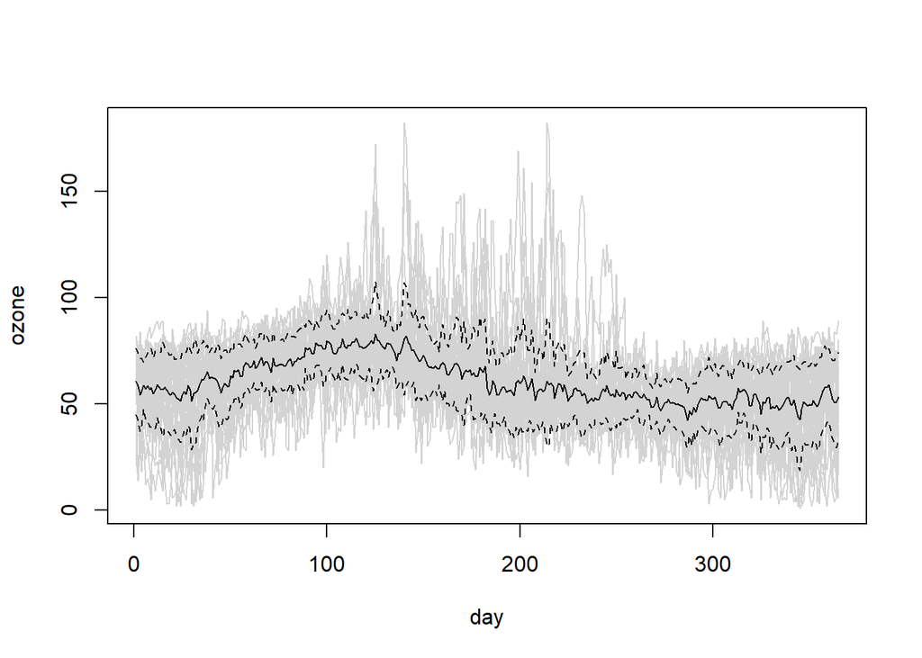

```r
plot(fd, col = "lightgray", legend = FALSE)
x <- coords(fd)
y <- f.mean(fd)
lines(x, y)
matlines(x, y + sqrt(f.var(fd, mean = y)) %o% c(-1, 1), col = 1, lty = 2)
```

# Trend estimation

The linear local trend estimates can be computed using the `locpol()` generic function (S3 methods `locpol.npf.data()` and `locpol.npf.bin()`):

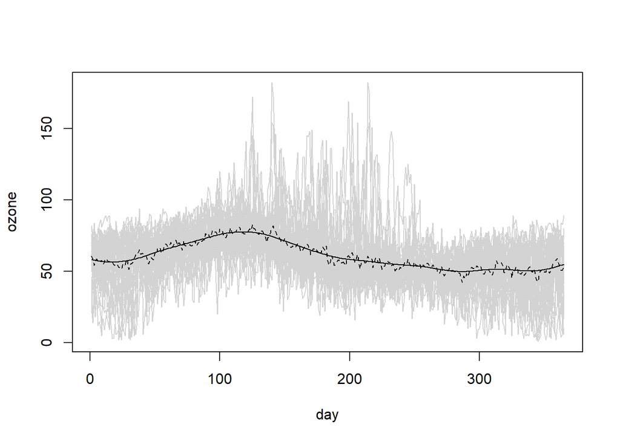

```r
trend.h <- 36
lp <- locpol(fd, h = trend.h)
# Plot
plot(fd, col = "lightgray", legend = FALSE)
lines(lp$data$x, lp$biny, lty = 2) # x = coords(fd)
lines(lp$data$x, lp$est)
```

The smoothing procedures in `npfda` (following `npsp` package) use binning to aggregate the data. For instance, instead of the previous code we can use:

```r
bin <- npf.binning(fd) # binning
lp <- locpol(bin, h = trend.h)
```

# Bandwidth selection

The trend estimates depends crucially on the bandwidth matrix $h$. A small bandwidth will produce undersmoothed estimates, whereas a big bandwidth will oversmooth the data. Although it may be subjectively choosed by eye, it could be very beneficial to have automatic selection criteria from the data.

The bandwidth can be selected through the `h.cv()` function. Traditional bandwidth selectors, such as cross validation (CV) or generalized cross validation (GCV), do not have a good performance for dependent data (Opsomer et al, 2001), since they tend to undersmooth the data. By default the modified cross-validation criteria (MCV; Chu and Marron, 1991) is used, by ignoring observations in a neighborhood $N(j)$ around $t_j$. Note that the ordinary CV approach is a particular case with $N(j)=\left\lbrace t_{j} \right\rbrace$.

In this case, the default bandwidth:

```r
# bin <- npf.binning(fd)
trend.h.cv <- h.cv(bin)$h
trend.h.cv
```

```
##          [,1]
## [1,] 4.947342
```

seems to undersmooth the data (since independence and homoscedasticity was implicitly assumed):

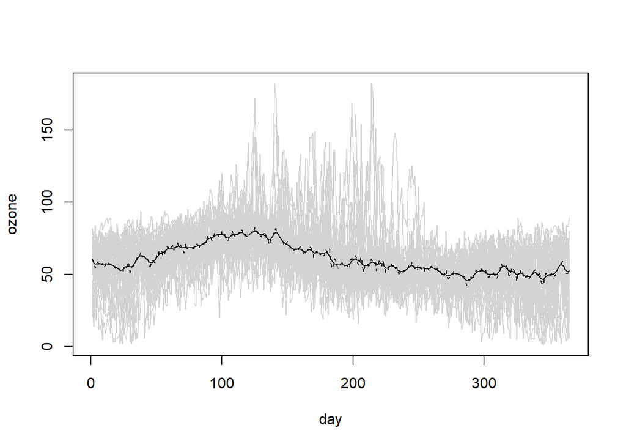

```r
# Linear Local trend estimates
lp.cv <- locpol(bin, h = trend.h.cv)
# Plot
with(lp.cv, {
  plot(data, col = "lightgray", legend = FALSE)
  lines(data$x, biny, lty = 2)
  lines(data$x, est)
})
```

An alternative is the corrected generalized cross-validation criterion (CGCV) that takes the temporal dependence into account, proposed in Francisco-Fernández and Opsomer (2005) for the spatial case. Nevertheless, the modeling of the dependence structure is previously required to use this approach in practice.

# Variance estimation

The linear local variance estimates can be computed using the `np.var()` generic function:

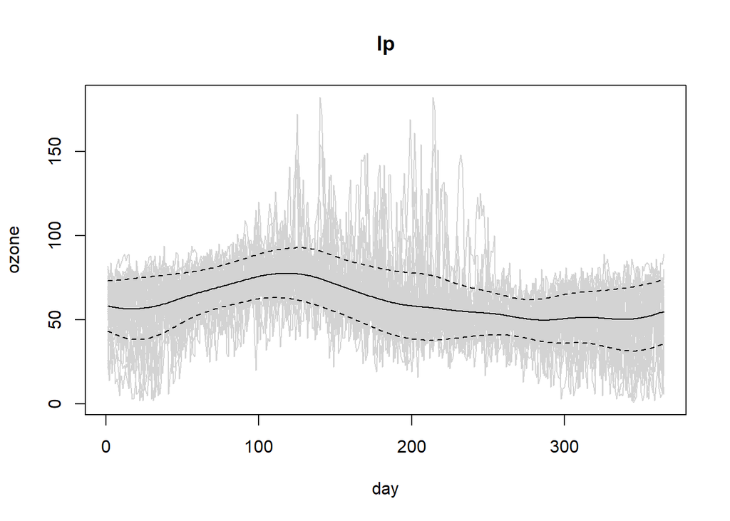

```r
var.h <- 33
lp.var <- np.var(lp, h = var.h)
# Plot data + estimated trend -+ estimated std. dev.
plot(lp, lp.var)
```

The bandwidth can also be selected using the `h.cv()` function:

```r
bin.res2 <- npf.bin.res2(lp)
var.h.cv <- h.cv(bin.res2)$h
var.h.cv
```

```
##          [,1]
## [1,] 6.941771
```

Nevertheless, as the default method assumes independence, the selected bandwidth undersmoothes the squared residuals:

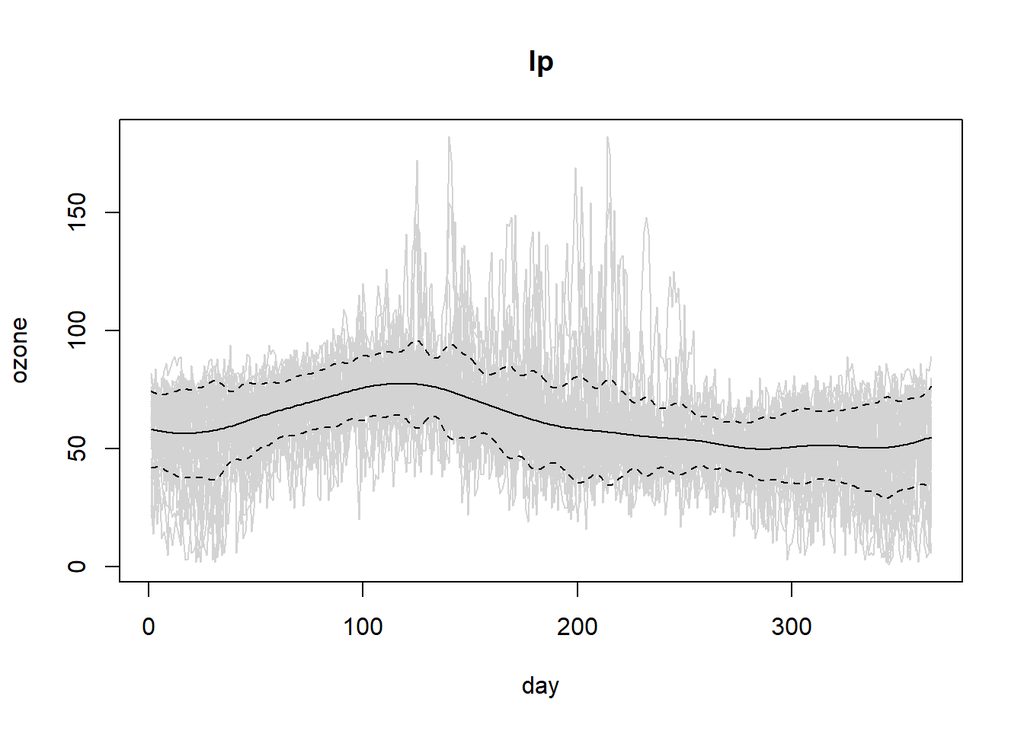

```r
# Linear Local variance estimate
lp.cv.var <- np.var(lp, h = var.h.cv)
# Plot data + estimated trend -+ estimated std. dev.
plot(lp, lp.cv.var)
```

# Variogram estimation

Local linear variogram estimates can be computed with the `np.svar()` generic function, in this case from standardized residuals. Function `h.cv()` may be used to select the corresponding bandwidth, minimizing the cross-validation relative squared error of the semivariogram estimates by default (see e.g. Fernández-Casal and Francisco-Fernández, 2014). Nevertheless, as the default criterion does not take into account the dependence between the sample semivariances, the resulting bandwidth should be increased to avoid under-smoothing the variogram estimates.

```r
bin.svar <- svar.bin(lp, lp.var, maxlag = 100)
svar.h <- 1.5*h.cv(bin.svar)$h
svar.h
```

```
##          [,1]
## [1,] 3.712871
```

```r
svar.np <- np.svar(bin.svar, h = svar.h)
# plot(svar.np)
```

A valid variogram estimate is obtained by fitting a “nonparametric” isotropic Shapiro-Botha variogram model (Shapiro and Botha, 1991), to the nonparametric pilot estimates, by using function `npsp::fitsvar.sb.iso()`.

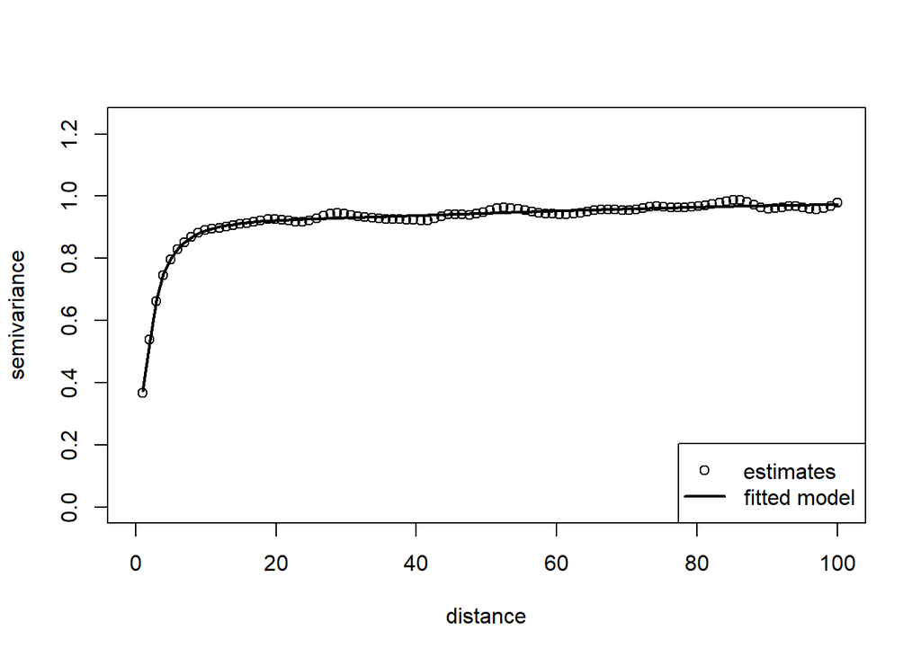

```r
svm <- fitsvar.sb.iso(svar.np, dk = 0)
plot(svm)
```

# Updating the estimates

The selection of optimal bandwidths for trend and variance approximation, require estimation of the small-scale variability of the process, leading to a circular problem. To avoid it, an iterative algorithm could be used.  
Starting with initial bandwidths (e.g. obtained by any of the available methods for independent data). At each iteration, the bandwidths are selected using the variance and variogram estimates computed in the previous iteration, and the model components are re-estimated. The algorithm can be considered to converge when there are no large changes in the selected bandwidths (which would be due to similar small-scale variability estimates). In practice, just one iteration of this algorithm is usually sufficient.

In this case, as the initial bandwidths were purposely set close to their convergence values, a new selection of the bandwidth for the trend estimation:

```r
# Estimated correlation matrix
cor.est <- varcov(svm, lp$data$x)
# Trend bandwidth selection (under heteroscedasticity and dependence)
trend.h.new <- h.cv(bin, lp.var, cor = cor.est)$h
trend.h.new
```

```
##          [,1]
## [1,] 36.37871
```

results in a value almost the same as the initial one:

```r
error.trend.h <- abs(trend.h/trend.h.new - 1)
error.trend.h
```

```
##            [,1]
## [1,] 0.01041033
```

and the same happens for the variance estimation:

```r
# Variance bandwidth selection (under heteroscedasticity and dependence)
var.h.new <- h.cv(bin.res2, lp.var, cor = cor.est)$h
var.h.new
```

```
##          [,1]
## [1,] 33.85016
```

```r
error.var.h <- abs(var.h/var.h.new - 1)
error.var.h
```

```
##            [,1]
## [1,] 0.02511527
```

Therefore, it would not be necessary to iterate and we can consider the previous estimates to be the definitive ones.

```r
np.fit <- npf.model(lp, lp.var, svm)
```

# Automatic modeling

The iterative procedure for the joint estimation of the trend, the variance and the semivariogram is implemented in `npf.fit()` function:

```r
np.fit2 <- npf.fit(fd, var.h = 30, maxlag = 100, verbose = TRUE)
```

```
##
## Iteration: 0
## Trend bandwidth: 9.894684
## Variance bandwidth: 30
## Semivariogram bandwidth: 3.712871
##
## Iteration: 1
## Trend bandwidth: 36.07592 , Error: 0.7257261
## Variance bandwidth: 32.84395 , Error: 0.08658973
##
## Iteration: 2
## Trend bandwidth: 36.07668 , Error: 2.090298e-05
## Variance bandwidth: 33.10639 , Error: 0.007927349
```

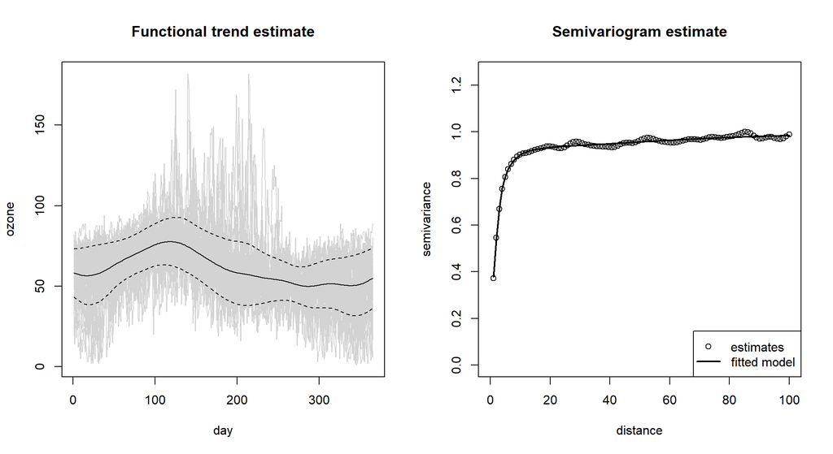

```r
plot(np.fit2)
```

# References

Castillo-Páez, S., Fernández-Casal, R., García-Soidán, P. (2019). A nonparametric bootstrap method for spatial data. *Comput. Stat. Data An.*, **137**, 1–15.

Chu, C. K. and Marron, J. S. (1991). Comparison of Two Bandwidth Selectors with Dependent Errors. *The Annals of Statistics* **19**, 1906–1918.

Fan, J. and Gijbels, I. (1996). *Local polynomial modelling and its applications*. Chapman & Hall, London.

Fernández-Casal, R. (2023). npsp: Nonparametric Spatial Statistics. R package version 0.7-12. *https://github.com/rubenfcasal/npsp*.

Fernández-Casal R, Francisco-Fernández M (2014) Nonparametric bias-corrected variogram estimation under non-constant trend, *Stoch. Environ. Res. Ris. Assess.*, **28**, 1247-1259, [DOI](https://doi.org/10.1007/s00477-013-0817-8).

Francisco-Fernández, M. and Opsomer, J. D. (2005). Smoothing parameter selection methods for nonparametric regression with spatially correlated errors. *The Canadian Journal of Statistics* **33**, 279–295.

Opsomer, J. D., Wang, Y. and Yang, Y. (2001). Nonparametric regression with correlated errors. *Statistical Science* **16**, 134–153.

Shapiro, A. and Botha, J.D. (1991). Variogram fitting with a general class of conditionally non-negative definite functions. *Computational Statistics and Data Analysis* **11**, 87–96.